# dblclick

Double-click a DOM element.

## Syntax

```javascript
.dblclick()
.dblclick(options)
.dblclick(position)
.dblclick(position, options)
.dblclick(x, y)
.dblclick(x, y, options)
```

### Usage

**Correct Usage**

```javascript
cy.get('button').dblclick() // Double click on button
cy.focused().dblclick() // Double click on el with focus
cy.contains('Welcome').dblclick() // Double click on first el containing 'Welcome'
```

**Incorrect Usage**

```javascript
cy.dblclick('button') // Errors, cannot be chained off 'cy'
cy.window().dblclick() // Errors, 'window' does not yield DOM element
```

### Arguments

**position** *(String)*

The position where the double click should be issued. The `center` position is the default position. Valid positions are `topLeft`, `top`, `topRight`, `left`, `center`, `right`, `bottomLeft`, `bottom`, and `bottomRight`.

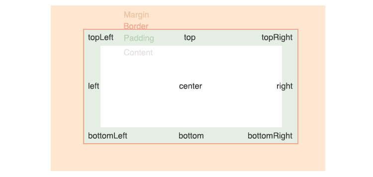

**x** *(Number)*

The distance in pixels from the element's left to issue the double click.

**y** *(Number)*

The distance in pixels from the element's top to issue the double click.

**options** *(Object)*

Pass in an options object to change the default behavior of `.dblclick()`.

| Option | Default | Description |
| --- | --- | --- |
| `altKey` | `false` | Activates the alt key (option key for Mac). Aliases: `optionKey`. |
| `animationDistanceThreshold` | [`animationDistanceThreshold`](https://docs.cypress.io/guides/references/configuration#Actionability) | The distance in pixels an element must exceed over time to be [considered animating](https://docs.cypress.io/guides/core-concepts/interacting-with-elements#Animations). |
| `ctrlKey` | `false` | Activates the control key. Aliases: `controlKey`. |
| `log` | `true` | Displays the command in the [Command log](https://docs.cypress.io/guides/core-concepts/test-runner#Command-Log) |
| `force` | `false` | Forces the action, disables waiting for actionability |
| `metaKey` | `false` | Activates the meta key (Windows key or command key for Mac). Aliases: `commandKey`, `cmdKey`. |
| `multiple` | `true` | Serially click multiple elements |
| `scrollBehavior` | [`scrollBehavior`](https://docs.cypress.io/guides/references/configuration#Actionability) | Viewport position to where an element [should be scrolled](https://docs.cypress.io/guides/core-concepts/interacting-with-elements#Scrolling) before executing the command |
| `shiftKey` | `false` | Activates the shift key. |
| `timeout` | [`defaultCommandTimeout`](https://docs.cypress.io/guides/references/configuration#Timeouts) | Time to wait for `.dblclick()` to resolve before timing out |
| `waitForAnimations` | [`waitForAnimations`](https://docs.cypress.io/guides/references/configuration#Actionability) | Whether to wait for elements to [finish animating](https://docs.cypress.io/guides/core-concepts/interacting-with-elements#Animations) before executing the command. |

### Yields

- `.dblclick()` yields the same subject it was given from the previous command.

## Examples

### No Args

#### Double click an anchor link

```javascript
cy.get('a#nav1').dblclick() // yields the <a>
```

### Position

#### Specify a position of the element to double click

Click the bottom center of the button.

```javascript
cy.get('button').dblclick('bottom')
```

### Coordinates

#### Specify coordinates relative to the top left corner

The double click below will be issued inside of the element (30px from the left and 10px from the top).

```javascript
cy.get('button').dblclick(30, 10)
```

### Options

#### Force a double click regardless of its actionable state

Forcing a double click overrides the [actionable checks](https://docs.cypress.io/guides/core-concepts/interacting-with-elements#Forcing) Cypress applies and will automatically fire the events.

```javascript
cy.get('button').dblclick({ force: true })
```

#### Force a double click with position argument

```javascript
cy.get('button').dblclick('topRight', { force: true })
```

#### Force a double click with relative coordinates

```javascript
cy.get('button').dblclick(60, 60, { force: true })
```

#### Double click all buttons found on the page

By default, Cypress will iteratively apply the double click to each element and will also log to the [Command Log](https://docs.cypress.io/guides/core-concepts/test-runner#Command-Log) multiple times.

You can turn this off by passing `multiple: false` to `.dblclick()`.

```javascript
cy.get('button').dblclick({ multiple: false })
```

#### Double click with key combinations

The `.dblclick()` command may also be fired with key modifiers in order to simulate holding key combinations while double clicking, such as `SHIFT + double click`.

> You can also use key combinations during .type(). This offers options to hold down keys across multiple commands. See Key Combinations for more information.

The following modifiers can be combined with `.dblclick()`.

| Option | Notes |
| --- | --- |
| `altKey` | Activates the alt key (option key for Mac). Aliases: `optionKey`. |
| `ctrlKey` | Activates the control key. Aliases: `controlKey`. |
| `metaKey` | Activates the meta key (Windows key or command key for Mac). Aliases: `commandKey`, `cmdKey`. |
| `shiftKey` | Activates the shift key. |

##### Alt click

```javascript
// execute ALT + dblclick on the first <li>
cy.get('li:first').dblclick({
  altKey: true,
})
```

## Notes

### Actionability

#### The element must first reach actionability

`.dblclick()` is an "action command" that follows all the rules of [Actionability](https://docs.cypress.io/guides/core-concepts/interacting-with-elements).

## Rules

### Requirements

- `.dblclick()` requires being chained off a command that yields DOM element(s).

### Assertions

- `.dblclick()` will automatically wait for the element to reach an [actionable state](https://docs.cypress.io/guides/core-concepts/interacting-with-elements)
- `.dblclick()` will automatically [retry](https://docs.cypress.io/guides/core-concepts/retry-ability) until all chained assertions have passed

### Timeouts

- `.dblclick()` can time out waiting for the element to reach an [actionable state](https://docs.cypress.io/guides/core-concepts/interacting-with-elements) .
- `.dblclick()` can time out waiting for assertions you've added to pass.

## Command Log

*Double click on a div*

```javascript
cy.get('.action-div').dblclick()
```

The commands above will display in the Command Log as:

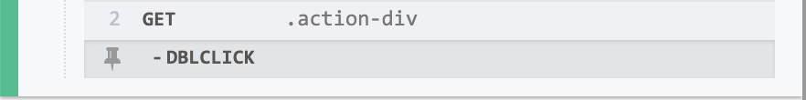

When clicking on `dblclick` within the command log, the console outputs the following:

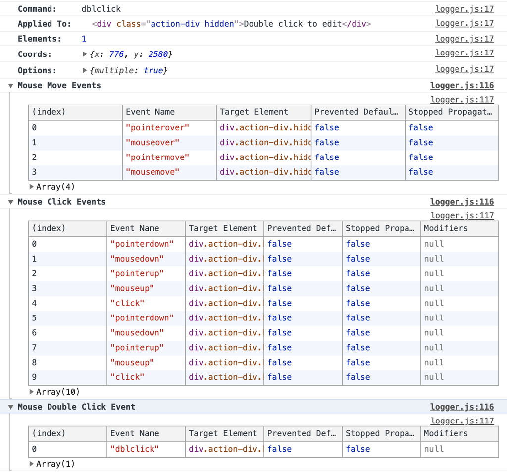

## History

| Version | Changes |
| --- | --- |
| [6.1.0](https://docs.cypress.io/guides/references/changelog#6-1-0) | Added option `scrollBehavior` |
| [3.5.0](https://docs.cypress.io/guides/references/changelog#3-5-0) | Added support for options `force` and `multiple`. |
| [3.5.0](https://docs.cypress.io/guides/references/changelog#3-5-0) | Added support for `position`, `x`, and `y` arguments. |
| [3.5.0](https://docs.cypress.io/guides/references/changelog#3-5-0) | Added sending `mouseover`, `mousemove`, `mouseout`, `pointerdown`, `pointerup`, and `pointermove` during `.dblclick()`. |

## See also

- `.click()`
- `.rightclick()`

© 2017 Cypress.io  
Licensed under the MIT License.  
https://docs.cypress.io/api/commands/dblclick